# New York Times and Met API Analysis

Author

Ellie Wilser

## Introduction and Approach

For this assignment, I wanted to try something different and use Claude code. I had the idea of comparing NYT coverage with another source. I wanted to merge my interests in art and data science into one project, so I decided to focus on artist coverage. I didn’t know what other APIs I could use to compared to, so I asked Claude to recommend a few. Claude mentioned that the Met has a free API, and I could compare coverage between The New York Times and The MET.

I used Claude code to create the following API structure for the assignment. At first, Claude returned the code with little explanation, so I asked for a detailed section explaining the code and an emphasis on the parameters used in calling the APIs.

As well, I specifically asked Claude to leave out the analysis because I did not want Claude to create my entire assignment. I plan to examine how artist coverage compares between the MET and NYT over time. I chose 5 different artists to examine, that are from different time periods.

Below is the code that Claude created for the 2 different APIs.

## How the API code works

**Note**

This section was written with Claude (Anthropic’s AI assistant).

The data comes from two APIs. The code that called them is shown below for reference, but it is not run when this document renders (`eval: false`). Its results were saved to three CSV files, and the document loads those instead, so rendering never calls the APIs.

| File | Contents |
| --- | --- |
| `nyt_by_year.csv` | NYT Arts articles per artist per year, plus yearly Arts totals |
| `met_ids.csv` | Every Met object ID found for each artist |
| `met_objects.csv` | One record per Met object (acquisition year, date, type) |

### Artists and years

The `artists` table gives each artist two search names. The Met catalogs some artists under a longer name (Goya is “Francisco de Goya”), and the NYT search uses only the surname because articles often drop the first name. The NYT counts cover 1981–2025, because section names on older NYT articles are unreliable and the Arts filter would quietly drop them.

### New York Times Article Search API

Endpoint: `https://api.nytimes.com/svc/search/v2/articlesearch.json`

`nyt_hits()` makes one request per artist per year and keeps only the number of matching articles (`hits`), not the articles themselves.

| Parameter | Value in this project | What it does |
| --- | --- | --- |
| `q` | `"Warhol"` | Search text. The quotes make it match the exact name. |
| `fq` | `section.name:"Arts"` | Filter query. Keeps only articles from the Arts section. |
| `begin_date` | `19810101` | First publication date to include (YYYYMMDD). |
| `end_date` | `19811231` | Last publication date to include. With `begin_date`, this selects one year. |
| `api-key` | from `.Renviron` | Personal key from the NYT developer site, read with `Sys.getenv("NYT_API_KEY")`. |

When `q` is left out, the request counts every Arts article that year. Those totals let each artist’s count be turned into a share of all Arts coverage, because the number of Arts articles changes from year to year.

**Limits.** The NYT allows about 5 requests per minute and 500 per day. The code waits 12 seconds after each request, and `req_retry()` waits a full minute and tries again if the API answers 429 (too many requests). 5 artists × 45 years plus 45 yearly totals is 270 requests, about 55 minutes.

**Field names.** The NYT renamed its filter fields. The old filter `section_name:("Arts")` returns 0 results without an error, so the code uses `section.name`.

### Met Collection API

No key is needed. The code uses two endpoints.

**1. Search** (`/public/collection/v1.1/search`) returns the IDs of matching objects. The Met retired the original `/v1/search` on 2026-10-01, so this uses `/v1.1`.

| Parameter | Value in this project | What it does |
| --- | --- | --- |
| `q` | `"Andy Warhol"` | Search text. Without quotes the search is fuzzy and matches other artists. |
| `artistOrCulture` | `true` | Search only the artist and culture fields, not titles or descriptions. |
| `limit` | `500` | IDs per request. 500 is the most the API returns at once. |
| `offset` | `0`, `500`, … | Where to start. Dürer has 843 objects, so his IDs take two requests. |

The response contains `total` (the number of matches) and `objectIDs`. `met_object_ids()` keeps raising `offset` by 500 until it has all of them.

**2. Object** (`/public/collection/v1/objects/{objectID}`) returns the full record for one object. `met_object()` keeps these fields:

| Field | Meaning |
| --- | --- |
| `accessionYear` | Year the Met acquired the object (used for counts by year) |
| `objectBeginDate` | Earliest year the object was made |
| `classification` | Type of object, such as Prints, Drawings or Paintings |
| `artistDisplayName` | Artist name as the Met catalogs it |
| `isHighlight` | Whether the Met lists it as a highlight of the collection |

A few IDs in search results no longer exist and return 404. Those rows are saved with their status code so they can be filtered out.

**Limits.** The Met blocks rapid requests with HTTP 403, so the code pauses 1 second before each request and retries on 403, 429 and 503. The five artists have about 1,780 objects, so collecting them took about 30–40 minutes.

### How the results were saved

`collect_nyt()` and `collect_met()` append each result to its CSV as soon as it arrives, and skip anything already saved. If a run stopped partway, running it again continued where it left off. To download fresh data, delete the CSV files and run the `collect-nyt` and `collect-met` chunks in RStudio.

```r
library(tidyverse)
library(httr2)
library(ggplot2)

nyt_file <- "nyt_by_year.csv"
met_file <- "met_objects.csv"
met_ids_file <- "met_ids.csv"

artists <- tribble(
  ~artist,          ~period,                ~met_name,           ~nyt_name,
  "Albrecht Dürer", "Northern Renaissance", "Albrecht Dürer",    "Dürer",
  "Rembrandt",      "Dutch Golden Age",     "Rembrandt",         "Rembrandt",
  "Francisco Goya", "Romanticism",          "Francisco de Goya", "Goya",
  "Frida Kahlo",    "Mexican modernism",    "Frida Kahlo",       "Kahlo",
  "Andy Warhol",    "Pop Art",              "Andy Warhol",       "Warhol"
)

years <- 1981:2025
```

### New York Times: articles per year

```r
# NYT: number of Arts-section articles in one year.
# term = NULL counts every Arts article that year (used to normalize).
nyt_hits <- function(term, year) {
  resp <- request("https://api.nytimes.com/svc/search/v2/articlesearch.json") |>
    req_url_query(
      q = if (!is.null(term)) paste0('"', term, '"'),
      fq = 'section.name:"Arts"',
      begin_date = paste0(year, "0101"),
      end_date = paste0(year, "1231"),
      `api-key` = Sys.getenv("NYT_API_KEY")
    ) |>
    # 429 = too many requests; wait a full minute before trying again
    req_retry(max_tries = 4, backoff = \(i) 60) |>
    req_perform() |>
    resp_body_json()
  Sys.sleep(12)  # stay under 5 requests/minute
  resp$response$meta$hits %||% resp$response$metadata$hits %||% NA_integer_
}

# Request every artist-year (plus the yearly Arts total) that isn't saved yet,
# appending each result to the CSV as soon as it arrives
collect_nyt <- function() {
  todo <- expand_grid(artist = c(artists$artist, "All Arts articles"), year = years)
  if (file.exists(nyt_file)) {
    todo <- anti_join(todo, read_csv(nyt_file, show_col_types = FALSE),
                      by = c("artist", "year"))
  }
  if (nrow(todo) == 0) return(invisible())
  message(nrow(todo), " NYT requests to make (about ",
          ceiling(nrow(todo) / 5), " minutes)")

  terms <- set_names(artists$nyt_name, artists$artist)
  for (i in seq_len(nrow(todo))) {
    row <- todo[i, ]
    term <- if (row$artist == "All Arts articles") NULL else terms[[ row$artist]]
    row$hits <- nyt_hits(term, row$year)
    write_csv(row, nyt_file, append = file.exists(nyt_file))
    message(row$artist, " ", row$year, ": ", row$hits)
  }
}
```

```r
collect_nyt()
```

### The Met: objects acquired per year

```r
# Met: all object IDs for an artist, 500 at a time
met_object_ids <- function(met_name) {
  ids <- integer()
  offset <- 0
  repeat {
    Sys.sleep(1)  # the Met returns 403 for rapid requests
    resp <- request("https://collectionapi.metmuseum.org/public/collection/v1.1/search") |>
      req_user_agent("Data 607 class project") |>
      # quote the name so the search matches the full name only
      req_url_query(artistOrCulture = "true", limit = 500, offset = offset,
                    q = paste0('"', met_name, '"')) |>  # keep q last
      req_retry(max_tries = 4,
                is_transient = \(resp) resp_status(resp) %in% c(403, 429, 503)) |>
      req_perform() |>
      resp_body_json()
    page <- unlist(resp$objectIDs)
    ids <- c(ids, page)
    offset <- offset + 500
    if (length(page) == 0 || offset >= resp$total) break
  }
  unique(ids)
}

# Met: the fields we need from one object record.
# Some IDs in search results no longer exist (404); those come back as NA.
met_object <- function(id) {
  Sys.sleep(1)
  resp <- request("https://collectionapi.metmuseum.org/public/collection/v1/objects") |>
    req_url_path_append(id) |>
    req_user_agent("Data 607 class project") |>
    req_retry(max_tries = 4,
              is_transient = \(resp) resp_status(resp) %in% c(403, 429, 503)) |>
    req_error(is_error = \(resp) FALSE) |>
    req_perform()
  # keep the same columns either way so rows line up in the CSV
  obj <- if (resp_status(resp) == 200) resp_body_json(resp) else list()
  tibble(
    objectID          = id,
    status            = resp_status(resp),
    artistDisplayName = obj$artistDisplayName %||% NA,
    title             = obj$title %||% NA,
    classification    = obj$classification %||% NA,
    accessionYear     = as.character(obj$accessionYear %||% NA),
    objectBeginDate   = obj$objectBeginDate %||% NA,
    isHighlight       = obj$isHighlight %||% NA
  )
}

# Fetch every object record that isn't saved yet, appending as we go.
# Each artist's ID list is saved too, so later runs skip the search.
collect_met <- function() {
  saved <- if (file.exists(met_file)) {
    read_csv(met_file, show_col_types = FALSE, col_types = cols(accessionYear = "c"))
  } else {
    tibble(artist = character(), objectID = integer())
  }
  saved_ids <- if (file.exists(met_ids_file)) {
    read_csv(met_ids_file, show_col_types = FALSE)
  } else {
    tibble(artist = character(), objectID = integer())
  }

  for (i in seq_len(nrow(artists))) {
    artist <- artists$artist[i]
    if (artist %in% saved_ids$artist) {
      ids <- saved_ids$objectID[saved_ids$artist == artist]
    } else {
      ids <- met_object_ids(artists$met_name[i])
      # an artist with no objects is saved with an NA ID
      write_csv(tibble(artist = artist, objectID = if (length(ids)) ids else NA_integer_),
                met_ids_file, append = file.exists(met_ids_file))
    }
    ids <- setdiff(na.omit(ids), saved$objectID[saved$artist == artist])
    message(artists$artist[i], ": ", length(ids), " Met objects to fetch")
    for (id in ids) {
      row <- met_object(id) |> mutate(artist = artists$artist[i], .before = 1)
      write_csv(row, met_file, append = file.exists(met_file))
    }
  }
}
```

```r
collect_met()
```

### Loading the saved data

```r
nyt <- read_csv(nyt_file, show_col_types = FALSE)

met <- read_csv(met_file, show_col_types = FALSE, col_types = cols(accessionYear = "c")) |>
  filter(status == 200) |>
  mutate(accession_year = as.integer(str_extract(accessionYear, "\\d{4}")))
```

### Combining the two sources

```r
nyt_yearly <- nyt |>
  filter(artist != "All Arts articles") |>
  left_join(nyt |>
              filter(artist == "All Arts articles") |>
              select(year, arts_total = hits),
            by = "year") |>
  rename(nyt_articles = hits) |>
  mutate(nyt_share = nyt_articles / arts_total)

met_yearly <- met |>
  filter(!is.na(accession_year)) |>
  count(artist, year = accession_year, name = "met_acquired")

# One row per artist per year, 1981–2025, with 0 where nothing happened
yearly <- expand_grid(artist = artists$artist, year = years) |>
  left_join(nyt_yearly, by = c("artist", "year")) |>
  left_join(met_yearly, by = c("artist", "year")) |>
  mutate(met_acquired = replace_na(met_acquired, 0L)) |>
  left_join(select(artists, artist, period), by = "artist")
```

### The data

```r
yearly
```

| artist | year | nyt_articles | arts_total | nyt_share | met_acquired | period |
| --- | --- | --- | --- | --- | --- | --- |
| Albrecht Dürer | 1981 | 11 | 5503 | 0.0019989097 | 5 | Northern Renaissance |
| Albrecht Dürer | 1982 | 13 | 5759 | 0.0022573363 | 0 | Northern Renaissance |
| Albrecht Dürer | 1983 | 6 | 6097 | 0.0009840905 | 2 | Northern Renaissance |
| Albrecht Dürer | 1984 | 0 | 7267 | 0.0000000000 | 35 | Northern Renaissance |
| Albrecht Dürer | 1985 | 10 | 6899 | 0.0014494854 | 0 | Northern Renaissance |
| Albrecht Dürer | 1986 | 12 | 6718 | 0.0017862459 | 24 | Northern Renaissance |
| Albrecht Dürer | 1987 | 8 | 6821 | 0.0011728486 | 0 | Northern Renaissance |
| Albrecht Dürer | 1988 | 14 | 5834 | 0.0023997257 | 0 | Northern Renaissance |
| Albrecht Dürer | 1989 | 16 | 5592 | 0.0028612303 | 0 | Northern Renaissance |
| Albrecht Dürer | 1990 | 7 | 5013 | 0.0013963694 | 0 | Northern Renaissance |

[output cut: 215 more lines]

`met` holds every Met object record, including acquisitions from before 1981, which are left out of `yearly` so both sources cover the same years.

## Analysis

### Comparing NYT Coverage

For my analysis, first I will look at NYT coverage over time and compare artists.

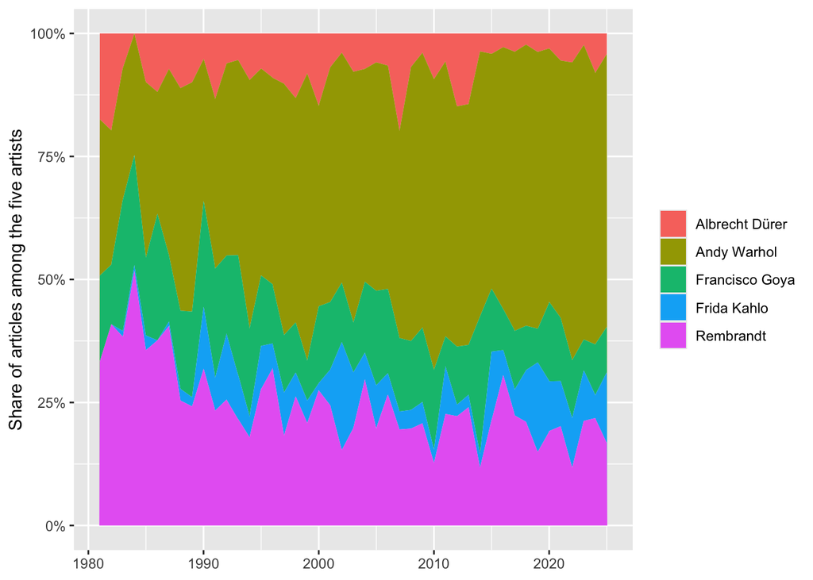

```r
yearly |>
  ggplot(aes(x = year, y = nyt_articles, fill = artist)) +
  geom_area(position = "fill") +
  scale_y_continuous(labels = scales::percent) +
  labs(y = "Share of articles among the five artists",
       x = NULL, fill = NULL)
```

The graph above shows that Andy Warhol dominates the percent share of the articles among the 5 chosen artists. After seeing this graph, I am wondering if the amount of article for the new artist’s, Kahlo and Warhol, and older artist’s, Goya, Rembrandt, and Durer have a similar trend.

### Comparing Trend of New and Older Artist

I first started by preparing the data for the visualization. For my visualization, I want to show the individual lines, as well as, a total line to show how certain artist’s might be skewing the trends.

```r
yearly2 <- yearly |>
  mutate(group = if_else(artist %in% c("Frida Kahlo", "Andy Warhol"),
                         "Newer (20th century)", "Older (1400s–1800s)"))
```

```r
group_totals <- yearly2 |>
  group_by(group, year) |>
  summarise(nyt_articles = sum(nyt_articles), .groups = "drop")
```

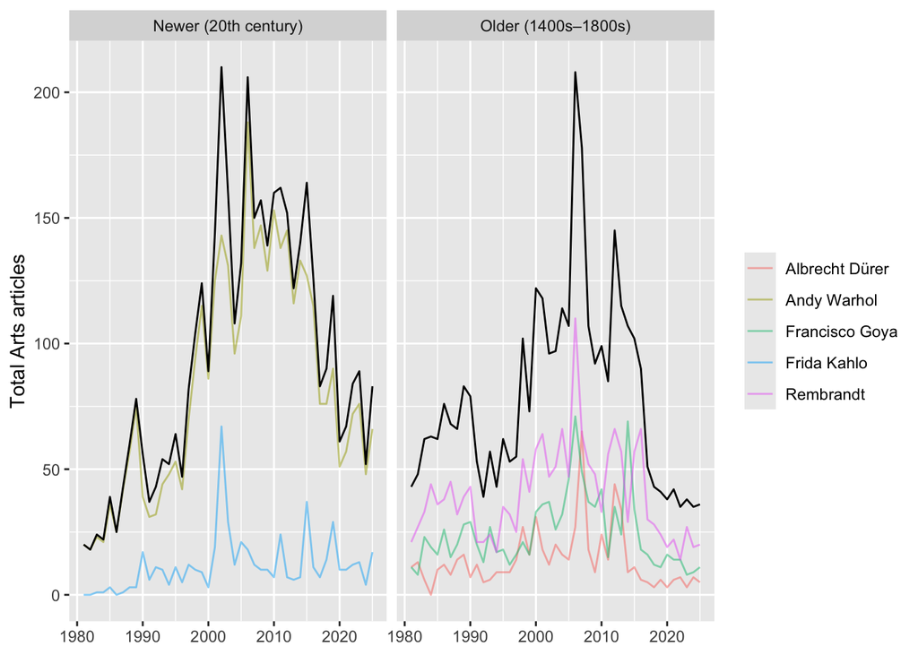

```r
ggplot(yearly2, aes(x = year, y = nyt_articles)) +
  geom_line(aes(color = artist), alpha = 0.5) +
  geom_line(data = group_totals, color="black") +
  facet_wrap(~ group) +
  labs(y = "Total Arts articles", x = NULL, color = NULL)
```

### Andy Warhol Media Coverage and Art Acquisitions

It appears that Andy Warhol has the best coverage for the NYT, and I will be using him as a case study for the rest of the assignment. I want to see if there is a correlation between his piece’s being acquired at the Met and his coverage in the NYT.

First, I will prepare the data to compare the coverage.

```r
warhol_nyt <- filter(yearly, artist == "Andy Warhol")
warhol_met <- met |>
  filter(artist == "Andy Warhol", !is.na(accession_year)) |>
  count(year = accession_year)

vis_data <- bind_rows(
    warhol_met |>
      transmute(year, source = "Met acquisitions", n),
    warhol_nyt |>
      transmute(year, source = "NYT articles", n = nyt_articles)
  ) |>
  arrange(source, year) |>
  group_by(source) |>
  mutate(cumulative_share = cumsum(n) / sum(n)) |>
  ungroup()
```

I decided to examine the cumulative share of the Met’s acquisition of his works and share of articles that mentioned him.

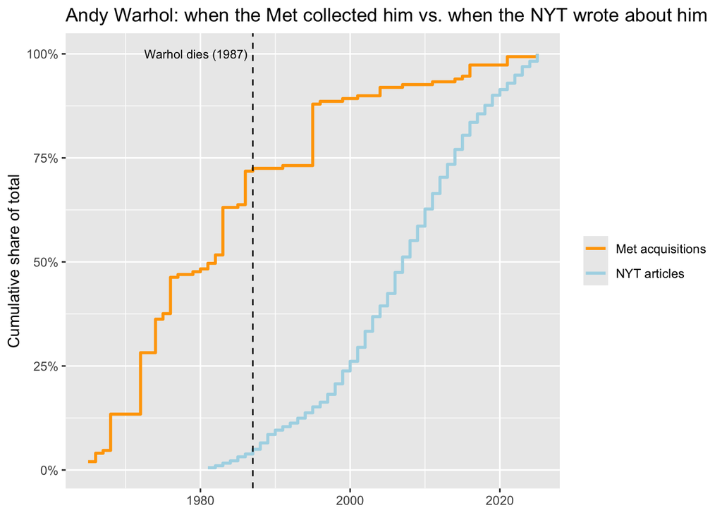

```r
ggplot(vis_data, aes(year, cumulative_share, color = source)) +
  geom_step(linewidth = 1) +
  geom_vline(xintercept = 1987, linetype = "dashed") +
  annotate("text", x = 1987, y = 1, label = "Warhol dies (1987)",
           hjust = 1.05, size = 3) +
  scale_y_continuous(labels = scales::percent) +
  scale_color_manual(values = c("Met acquisitions" = "orange",
                                "NYT articles" = "lightblue")) +
  labs(title = "Andy Warhol: when the Met collected him vs. when the NYT wrote about him",
       x = NULL, y = "Cumulative share of total", color = NULL)
```

From the graph above, it appears that the Met acquired much of Warhol’s work before he died, about 75% which is right around the NYT data starts. Due to this lag, it does not appear to be a strong relationship between Met acquisitions and NYT media coverage.

## Conclusion

This assignment gave me a great opportunity to work with API’s using Claude, but also get an understand on how the API calls work in R. It was interesting seeing how the NYT API worked very similarly to the Met API, this makes me excited to work with more APIs in the future.

In terms of analysis, I found it very interesting to see the different coverage of the 5 chosen artist. I was expecting Kahlo to have more articles, and I was surprise to see Andy Warhol having the most articles out the chosen artist. My biggest surprise in the analysis was the sharp decrease in number of articles about the 5 chosen artist, as well as, the large spike for all around 2006 to 2008. I wonder if other artist’s have similar trends in NYT coverage.

When a Museum acquires a piece of art work, it often happens from donations and purchasing. This may not match directly with media coverage. Future analysis might compare Google Searches with NYT articles, this would show if the NYT covers artists more when they are socially relevant.